# Bioestadística Fundamental

Departamento de Estadística, Sede Bogotá

## Contenido

### Parte I: Modelo de efectos aleatorios

- Efectos fijos vs. efectos aleatorios.
- Modelo de un factor aleatorio.
- Componentes de varianza.
- Ejemplo: fincas cafeteras del Huila.

### Parte II: Modelos de dos factores

- Dos factores aleatorios.
- Modelo mixto: variedad fija y finca aleatoria.
- Cuadrados medios esperados y prueba F correcta.
- Estimación de efectos y componentes de varianza.

### Parte III: Tamaño de muestra y CME esperados

- Tamaño de muestra con efectos aleatorios.
- Reglas para los cuadrados medios esperados.
- Pruebas F aproximadas: Satterthwaite.

### Parte IV: Estimación de componentes de varianza

- Intervalos de confianza aproximados.
- Método de la muestra grande modificado.
- Estimación por máxima verosimilitud (REML).
- Taller en clase.

Experimentos con Factores Aleatorios

¿Qué cambia cuando los niveles de un factor no se eligen porque interesan en sí mismos, sino porque representan una muestra de una población más amplia?

Bioestadística Fundamental, Departamento de Estadística, UNAL Bogotá

## Motivación: no todos los factores son iguales

Hasta ahora, en el ANOVA de efectos fijos, los niveles de un factor (ej. cuatro fertilizantes específicos) son los **únicos** de interés: la conclusión se aplica solo a ellos. Pero en muchos experimentos agrícolas los niveles de un factor son apenas una **muestra aleatoria** de una población mucho más grande de niveles posibles.

Ejemplo: un agrónomo selecciona al azar **5 fincas** de la región cafetera del Huila (que tiene cientos de fincas) para medir el rendimiento. No le interesan esas 5 fincas en particular, sino qué tan **variable** es el rendimiento entre fincas de esa región en general.

## Efectos fijos vs. efectos aleatorios

Factor fijo

Los niveles son elegidos deliberadamente porque **interesan por sí mismos** (ej. tres variedades específicas de café). La conclusión se restringe a esos niveles. Se estiman los $\tau_i$ específicos.

Factor aleatorio

Los niveles son una **muestra aleatoria** de una población más amplia (ej. 5 fincas de cientos posibles). No interesan esas fincas en particular, sino la **varianza** $\sigma_\tau^2$ entre fincas en general.

La pregunta de investigación cambia: en efectos fijos preguntamos “¿cuál nivel es mejor?”; en efectos aleatorios preguntamos “¿cuánto varían los niveles entre sí?”

## Modelo de un factor aleatorio

El modelo de un factor con $a$ niveles aleatorios se escribe igual que el de efectos fijos, pero con un supuesto distinto sobre $\tau_i$:

Modelo de efectos aleatorios de un factor

$$y_{ij} = \mu + \tau_i + \varepsilon_{ij}
\qquad
\begin{cases}
i=1,\ldots,a \\
j=1,\ldots,n
\end{cases}$$
$$\tau_i \sim N(0,\sigma_\tau^2) \qquad \varepsilon_{ij}\sim N(0,\sigma^2) \qquad \tau_i \perp \varepsilon_{ij}$$

- $\mu$: media general de la población de niveles.
- $\tau_i$: efecto aleatorio del nivel $i$, ahora una **variable aleatoria**, no un parámetro fijo.
- $\sigma_\tau^2$: varianza entre niveles (componente de varianza de interés).
- $\sigma^2$: varianza del error experimental (dentro de cada nivel).

## Estructura de varianza del modelo aleatorio

Como $\tau_i$ y $\varepsilon_{ij}$ son ambas variables aleatorias independientes, la varianza de cualquier observación se descompone directamente:

Varianza de una observación

$$\text{Var}(y_{ij}) = \sigma_\tau^2 + \sigma^2$$

Dos observaciones del **mismo** nivel están correlacionadas: $\text{Cov}(y_{ij}, y_{ij'}) = \sigma_\tau^2$ para $j\neq j'$. Esto es la base de los modelos de efectos mixtos y multinivel.

La hipótesis de interés ya no es sobre medias específicas, sino: $H_0: \sigma_\tau^2 = 0$ vs. $H_1: \sigma_\tau^2 > 0$.

## Ejemplo: rendimiento del café entre fincas del Huila

Ejemplo: variabilidad entre fincas, Huila

Un investigador selecciona al azar **6 fincas** de la región cafetera del Huila (factor aleatorio, $a=6$) y mide el rendimiento (sacos/ha) en **5 parcelas** de cada finca ($n=5$, $N=30$). No interesa cuál finca rinde más, sino qué tan variable es el rendimiento entre fincas de la región.

| Parcela | Finca 1 | Finca 2 | Finca 3 | Finca 4 | Finca 5 | Finca 6 |
| --- | --- | --- | --- | --- | --- | --- |
| 1 | 71.5 | 64.9 | 80.8 | 61.6 | 67.3 | 68.8 |
| 2 | 74.9 | 71.2 | 76.0 | 66.0 | 65.7 | 70.7 |
| 3 | 68.4 | 67.2 | 82.2 | 72.1 | 64.6 | 69.1 |
| 4 | 69.5 | 67.0 | 79.1 | 68.2 | 64.6 | 61.7 |
| 5 | 73.0 | 67.6 | 84.7 | 65.5 | 66.0 | 62.8 |
| $\bar y_{i.}$ | 71.46 | 67.58 | 80.56 | 66.68 | 65.64 | 66.62 |

Gran media $\bar y_{..}=69.76$ sacos/ha. Las medias por finca van de 65.64 a 80.56: hay variabilidad visible entre fincas.

## Tabla ANOVA del modelo aleatorio

La tabla ANOVA se construye **exactamente igual** que en el modelo de efectos fijos; lo que cambia es la interpretación de los cuadrados medios esperados.

| Fuente | SC | gl | CM | $E(CM)$ | F |  |
| --- | --- | --- | --- | --- | --- | --- |
| Finca | 803.01 | 5 | 160.60 | $\sigma^2+n\sigma_\tau^2$ | 17.38 |  |
| Error | 221.74 | 24 | 9.24 | $\sigma^2$ |  |  |
| Total | 1024.75 | 29 |  |  |  |  |

$F=160.60/9.24=17.38$, con valor-p $=2.74\times10^{-7} < 0.05$: se rechaza $H_0:\sigma_\tau^2=0$. Existe variabilidad real entre fincas.

## Estimación de los componentes de varianza

El método de momentos (también llamado **método ANOVA**) iguala cada cuadrado medio observado a su valor esperado y despeja los componentes de varianza:

Estimadores de momentos

$$\hat\sigma^2 = CM_E \qquad \hat\sigma_\tau^2 = \frac{CM_{Finca}-CM_E}{n}$$

$$\hat\sigma^2 = 9.24 \qquad \hat\sigma_\tau^2 = \frac{160.60-9.24}{5} = 30.27$$

La varianza total estimada de una observación es $\hat\sigma^2+\hat\sigma_\tau^2 = 39.51$ sacos²/ha².

## Interpretación: ¿qué proporción de la variabilidad es por finca?

Una pregunta natural en estos modelos es qué fracción de la variabilidad total se debe a la finca y cuál al error experimental dentro de la finca.

$$\text{Coeficiente de correlación intraclase: } \quad \rho = \frac{\hat\sigma_\tau^2}{\hat\sigma_\tau^2+\hat\sigma^2} = \frac{30.27}{39.51} = 0.766$$

Aproximadamente el **76.6%** de la variabilidad total del rendimiento se explica por diferencias entre fincas (suelo, manejo, microclima), y solo el 23.4% restante por variabilidad dentro de la misma finca (parcela a parcela).

Un $\rho$ alto sugiere que, para reducir la incertidumbre, conviene invertir en más fincas (más niveles del factor aleatorio) en lugar de más parcelas por finca.

## Errores comunes: modelo de un factor aleatorio

Advertencia: errores frecuentes

- Tratar un factor aleatorio (fincas seleccionadas al azar de una región) como si fuera fijo, e interpretar diferencias entre niveles específicos (esa finca particular vs. otra) cuando lo que interesa es la varianza general.
- Reportar solo la tabla ANOVA sin estimar $\sigma_\tau^2$, que es el parámetro de interés real.
- Olvidar verificar que los niveles del factor realmente fueron seleccionados al azar de una población más amplia; si se eligieron a propósito, el factor es fijo, no aleatorio.
- Confundir el coeficiente de correlación intraclase con un coeficiente de determinación $R^2$.

Modelos de Dos Factores

¿Qué ocurre cuando un experimento combina un factor de interés específico con un factor que representa una muestra aleatoria de una población?

## Diseño de dos factores aleatorios

Cuando **ambos** factores de un diseño cruzado son aleatorios, ninguno de los dos interesa por sus niveles específicos; interesan únicamente sus componentes de varianza.

Ejemplo conceptual: para evaluar la repetibilidad de un protocolo de medición del grado Brix en caña de azúcar, se seleccionan al azar **lotes** de caña y **operarios** que realizan la medición. Ni los lotes ni los operarios específicos interesan; interesa cuánta variabilidad introduce cada fuente.

Modelo de dos factores aleatorios (cruzado, con interacción)

$$y_{ijk}=\mu+\tau_i+\beta_j+(\tau\beta)_{ij}+\varepsilon_{ijk}$$
$$\tau_i\sim N(0,\sigma_\tau^2) \quad \beta_j\sim N(0,\sigma_\beta^2) \quad (\tau\beta)_{ij}\sim N(0,\sigma_{\tau\beta}^2) \quad \varepsilon_{ijk}\sim N(0,\sigma^2)$$

## Varianza en el modelo de dos factores aleatorios

Con dos factores aleatorios, la varianza total de una observación se descompone en **cuatro** componentes independientes:

Descomposición de la varianza

$$\text{Var}(y_{ijk}) = \sigma_\tau^2 + \sigma_\beta^2 + \sigma_{\tau\beta}^2 + \sigma^2$$

Este tipo de modelo es la base de los estudios de **repetibilidad y reproducibilidad** (R&R), comunes en el control de calidad de laboratorios agroindustriales (ej. medición de azúcares en caña, acidez en café).

## El modelo mixto de dos factores

El caso más frecuente en experimentación agrícola combina un factor **fijo** (el tratamiento de interés) con un factor **aleatorio** (el contexto donde se replica el experimento).

Ejemplo central: variedades de café en fincas del Huila

Se evalúan **3 variedades de café** (Castillo, Caturra, Tabi) — factor **fijo**, de interés específico para el productor — sembradas en **5 fincas** seleccionadas al azar de la región cafetera del Huila — factor **aleatorio**, muestra de la población de fincas de la región. Cada combinación variedad×finca se replica en 4 parcelas ($n=4$), para $N=60$ observaciones.

## Modelo mixto: notación

Modelo mixto de dos factores con interacción

$$y_{ijk}=\mu+\tau_i+\beta_j+(\tau\beta)_{ij}+\varepsilon_{ijk}$$
$$i=1,\ldots,a=3 \quad j=1,\ldots,b=5 \quad k=1,\ldots,n=4$$

- $\tau_i$: efecto **fijo** de la variedad $i$, con $\sum_i \tau_i = 0$ (parámetro, no variable aleatoria).
- $\beta_j$: efecto **aleatorio** de la finca $j$, $\beta_j\sim N(0,\sigma_\beta^2)$.
- $(\tau\beta)_{ij}$: interacción variedad×finca, también **aleatoria** porque involucra al factor aleatorio: $(\tau\beta)_{ij}\sim N(0,\sigma_{\tau\beta}^2)$.
- $\varepsilon_{ijk}\sim N(0,\sigma^2)$: error experimental.

## Datos del experimento: rendimiento (sacos/ha)

| Variedad | Finca 1 | Finca 2 | Finca 3 | Finca 4 | Finca 5 | $\bar y_{i..}$ |
| --- | --- | --- | --- | --- | --- | --- |
| Castillo | 74.90 | 66.70 | 76.23 | 71.43 | 76.50 | **73.15** |
| Caturra | 65.85 | 62.58 | 64.38 | 73.00 | 69.55 | **67.07** |
| Tabi | 63.60 | 66.85 | 65.08 | 69.40 | 73.70 | **67.73** |
| $\bar y_{.j.}$ | 68.12 | 65.38 | 68.56 | 71.28 | 73.25 | 69.32 |

Cada celda es el promedio de 4 parcelas. Castillo muestra el mayor promedio general (73.15), pero el patrón cambia de finca a finca: hay indicios de interacción.

## Tabla ANOVA del modelo mixto: sumas de cuadrados

| Fuente | SC | gl | CM |
| --- | --- | --- | --- |
| Variedad (fijo) | 445.51 | 2 | 222.75 |
| Finca (aleatorio) | 442.30 | 4 | 110.57 |
| Variedad×Finca | 365.31 | 8 | 45.66 |
| Error | 304.11 | 45 | 6.76 |
| Total | 1557.23 | 59 |  |

Hasta aquí, el cálculo de SC y CM es **idéntico** al de un modelo de efectos fijos. Lo que cambia es el cuadrado medio esperado de cada fuente, y en consecuencia el denominador correcto de la prueba F.

## Cuadrados medios esperados del modelo mixto

Para un diseño cruzado balanceado con variedad fija ($a=3$) y finca aleatoria ($b=5$, $n=4$ réplicas), los cuadrados medios esperados son:

| Fuente | $E(CM)$ |
| --- | --- |
| Variedad (fijo) | $\sigma^2+n\sigma_{\tau\beta}^2+\dfrac{nb}{a-1}\sum_i\tau_i^2$ |
| Finca (aleatorio) | $\sigma^2+na\,\sigma_\beta^2$ |
| Variedad×Finca | $\sigma^2+n\sigma_{\tau\beta}^2$ |
| Error | $\sigma^2$ |

Nótese que $E(CM_{Variedad})$ contiene el término $n\sigma_{\tau\beta}^2$: el denominador correcto para probar el factor fijo es $CM_{Variedad\times Finca}$, **no** $CM_E$.

## Prueba F correcta para el factor fijo (variedad)

Para que el cociente de cuadrados medios tenga esperanza 1 bajo $H_0$, el numerador y el denominador deben compartir todos los términos excepto el que se está probando.

F correcta para variedad (factor fijo)

$$F=\frac{CM_{Variedad}}{CM_{Variedad\times Finca}} \sim F_{a-1,\,(a-1)(b-1)} \quad \text{bajo } H_0:\tau_i=0\;\forall i$$

$$F=\frac{222.75}{45.66}=4.88 \qquad gl=(2,8) \qquad \text{valor-p}=0.041$$

## Por qué el denominador correcto importa

Usar $CM_E$ como denominador ignora que parte de la variabilidad observada entre variedades también está contaminada por la interacción variedad×finca, que es aleatoria.

[output not shown]

La conclusión cualitativa no cambia en este ejemplo (sigue siendo significativo), pero los grados de libertad del error caen de 45 a 8: la prueba correcta es mucho más conservadora, como corresponde a tener solo 5 fincas.

## Prueba F para el factor aleatorio (finca) y la interacción

**Finca (aleatorio):**
$$F=\frac{CM_{Finca}}{CM_{Variedad\times Finca}}=\frac{110.57}{45.66}=2.42 \qquad gl=(4,8) \qquad \text{valor-p}=0.134$$

**Interacción Variedad×Finca:**
$$F=\frac{CM_{Variedad\times Finca}}{CM_E}=\frac{45.66}{6.76}=6.76 \qquad gl=(8,45) \qquad \text{valor-p}<0.0001$$

La interacción **sí** usa $CM_E$ como denominador correcto (es la única fuente cuyo $E(CM)$ solo añade $\sigma^2$ al término propio). Hay evidencia fuerte de interacción: el desempeño relativo de las variedades cambia según la finca.

## Componentes de varianza del modelo mixto

Despejando los cuadrados medios esperados (método de momentos):

Estimadores de momentos

$$\hat\sigma^2=CM_E \qquad \hat\sigma_{\tau\beta}^2=\frac{CM_{V\times F}-CM_E}{n} \qquad \hat\sigma_\beta^2=\frac{CM_{Finca}-CM_{V\times F}}{na}$$

$$\hat\sigma^2=6.76 \qquad \hat\sigma_{\tau\beta}^2=\frac{45.66-6.76}{4}=9.73 \qquad \hat\sigma_\beta^2=\frac{110.57-45.66}{4(3)}=5.41$$

| Componente | Estimación | % de la varianza |
| --- | --- | --- |
| $\sigma_\beta^2$ (finca) | 5.41 | 24.7% |
| $\sigma_{\tau\beta}^2$ (interacción) | 9.73 | 44.4% |
| $\sigma^2$ (error) | 6.76 | 30.9% |

## Estimación de los efectos fijos (variedad)

Los efectos fijos de variedad se estiman con los promedios marginales, igual que en el ANOVA de un factor:

| Variedad | $\bar y_{i..}$ | $\hat\tau_i=\bar y_{i..}-\bar y_{...}$ |
| --- | --- | --- |
| Castillo | 73.15 | +3.84 |
| Caturra | 67.07 | -2.25 |
| Tabi | 67.73 | -1.59 |

Error estándar de la diferencia entre dos medias de variedad (usando $CM_{V\times F}$):
$$EE(\bar y_{i..}-\bar y_{i'..})=\sqrt{\frac{2\,CM_{V\times F}}{bn}}=\sqrt{\frac{2(45.66)}{20}}=2.14$$

## Conclusión con números reales

| Comparación | Diferencia | $t=\text{dif}/EE$ | $t_{0.025,8}=2.306$ |
| --- | --- | --- | --- |
| Castillo $-$ Caturra | 6.08 | 2.85 | Significativa |
| Castillo $-$ Tabi | 5.43 | 2.54 | Significativa |
| Caturra $-$ Tabi | $-0.66$ | $-0.31$ | No significativa |

**Conclusión:** existe evidencia de que la variedad afecta el rendimiento ($F=4.88$, $p=0.041$), con Castillo superando a Caturra y a Tabi en aproximadamente 5.4 a 6.1 sacos/ha. Sin embargo, la fuerte interacción variedad×finca ($p<0.0001$) indica que esta ventaja de Castillo no es uniforme: en algunas fincas el patrón se invierte, por lo que la recomendación de variedad debería matizarse según las condiciones locales.

## Errores comunes: modelo mixto

Advertencia: errores frecuentes

- Usar siempre $CM_E$ como denominador de la prueba F, sin verificar primero los cuadrados medios esperados de cada fuente.
- Olvidar que en un modelo mixto con interacción, el factor fijo se prueba contra $CM_{interacción}$, no contra $CM_E$.
- Interpretar $\sigma_\beta^2$ o $\sigma_{\tau\beta}^2$ como si fueran efectos de fincas específicas (son varianzas de una población, no efectos puntuales).
- Ignorar una interacción significativa y reportar solo el efecto principal del factor fijo, ocultando que su efecto depende del contexto (finca).

Tamaño de Muestra y Cuadrados Medios Esperados

¿Cuántos niveles del factor aleatorio y cuántas réplicas se necesitan? ¿Cómo se determina el denominador correcto de cada prueba F?

## Tamaño de muestra con efectos aleatorios

En el modelo de efectos fijos, el tamaño de muestra solo involucra el número de réplicas $n$ por tratamiento. Con un factor aleatorio aparece una **segunda decisión**: cuántos **niveles** del factor aleatorio incluir.

**Número de niveles aleatorios ($b$)**  
Cuántas fincas, lotes u operarios se seleccionan. Determina cuánto se puede generalizar a la población.

**Número de réplicas ($n$)**  
Cuántas parcelas por combinación. Reduce el error experimental, pero no aumenta la generalización a otras fincas.

En el ejemplo del café: aumentar $n$ (parcelas por finca) reduce $\sigma^2$, pero solo aumentar $b$ (número de fincas) reduce la incertidumbre sobre $\sigma_\beta^2$ y mejora los grados de libertad del denominador de la prueba F del factor fijo.

## Por qué los grados de libertad del factor aleatorio limitan la potencia

En el ejemplo del café, la prueba F de variedad usa $gl_2=(a-1)(b-1)=8$, que depende del número de **fincas**, no del número total de observaciones ($N=60$).

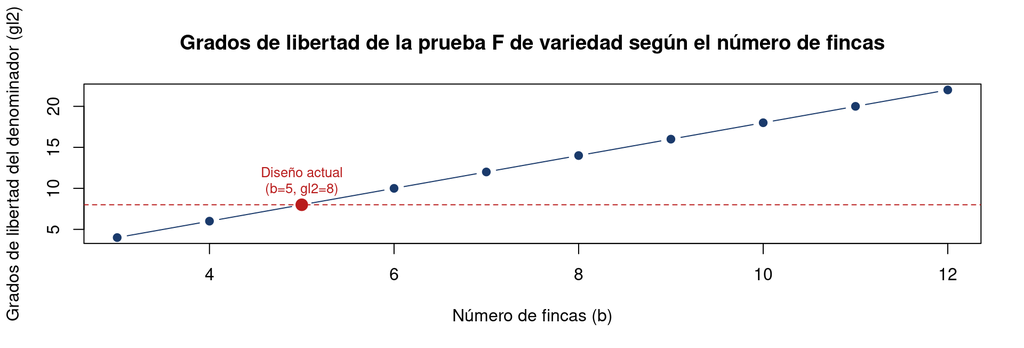

Agregar más parcelas por finca (aumentar $n$) **no** mueve esta curva: solo agregar más fincas lo hace. Por eso la planeación de tamaño de muestra con factores aleatorios exige decidir $b$ con cuidado.

## Reglas para los cuadrados medios esperados

Existe un algoritmo general (regla de Cornfield-Tukey) para determinar el $E(CM)$ de cualquier fuente en un diseño balanceado, según si cada factor es fijo o aleatorio.

**Algoritmo (versión resumida):** para cada fuente, su $E(CM)$ es $\sigma^2$ más la suma de las varianzas (o sumas de cuadrados de efectos fijos divididas por sus gl) de **todos los términos que contienen** a los subíndices de esa fuente, cada uno multiplicado por el producto de los tamaños de los subíndices **ausentes** en ese término, exceptuando los subíndices correspondientes a factores fijos.

En la práctica, basta construir una tabla de “reglas de subíndices” para identificar qué cuadrado medio sirve de denominador a cada fuente.

## Tabla de reglas para el ejemplo mixto

Para el modelo mixto Variedad (fija, $i$) × Finca (aleatoria, $j$) con réplicas ($k$), la tabla de reglas se construye así:

| Fuente | $i$ (fijo, $a=3$) | $j$ (aleat., $b=5$) | $k$ (réplica, $n=4$) | $E(CM)$ |
| --- | --- | --- | --- | --- |
| Variedad ($i$) | 0 | 1 | 1 | $\sigma^2+n\sigma_{\tau\beta}^2+nb\,\theta_\tau$ |
| Finca ($j$) | 1 | 0 | 1 | $\sigma^2+na\,\sigma_\beta^2$ |
| Variedad×Finca ($ij$) | 0 | 0 | 1 | $\sigma^2+n\sigma_{\tau\beta}^2$ |
| Error ($ijk$) | 0 | 0 | 0 | $\sigma^2$ |

Regla práctica: el denominador correcto de una fuente es el $CM$ de la fuente de mayor orden (más subíndices) cuyo $E(CM)$ coincide con el de la fuente bajo $H_0$, excepto el término que se está probando.

## Pruebas F aproximadas: motivación

En diseños más complejos (varios factores aleatorios, anidamientos), puede no existir ningún cuadrado medio simple cuyo $E(CM)$ coincida exactamente con el numerador bajo $H_0$.

Solución: construir un denominador **aproximado** como una combinación lineal de cuadrados medios disponibles, de modo que su esperanza coincida con la del numerador bajo $H_0$.

Combinación lineal de cuadrados medios

$$CM^{*}=CM_1+CM_2-CM_3$$
$$F^{*}=\frac{CM_{Numerador}}{CM^{*}}$$

## Método de Satterthwaite

Como $CM^{*}$ ya no es un cuadrado medio puro, su distribución no es exactamente $\chi^2$ escalada. El **método de Satterthwaite** aproxima sus grados de libertad efectivos:

Grados de libertad de Satterthwaite

$$gl^{*}=\frac{(CM_1+CM_2+\cdots)^2}{\dfrac{CM_1^2}{gl_1}+\dfrac{CM_2^2}{gl_2}+\cdots}$$

La idea general (sin entrar en la derivación completa) es encontrar los grados de libertad de una distribución $\chi^2$ que mejor “imite” la varianza de la combinación lineal $CM^{*}$. Software como R (paquete `lmerTest`) calcula esto automáticamente en modelos mixtos.

En nuestro ejemplo del café, el modelo es balanceado y el denominador $CM_{V\times F}$ es exacto: no se necesitó aproximación de Satterthwaite. Esta técnica se vuelve indispensable en diseños no balanceados o con anidamientos múltiples.

Estimación de Componentes de Varianza

Más allá del estimador puntual: ¿qué tan precisa es la estimación de $\sigma_\beta^2$ o $\sigma_{\tau\beta}^2$?

## Intervalos de confianza para componentes de varianza: la dificultad

Para una varianza simple $\sigma^2$ de una muestra normal, $\frac{(N-1)S^2}{\sigma^2}\sim\chi^2_{N-1}$ permite un IC exacto. Para $\sigma_\tau^2$ o $\sigma_\beta^2$, estimados como una **diferencia** de cuadrados medios, no existe una distribución exacta tan simple.

El problema: $\hat\sigma_\beta^2=\dfrac{CM_{Finca}-CM_{V\times F}}{na}$ es la diferencia de dos variables aleatorias proporcionales a $\chi^2$, y la diferencia de dos $\chi^2$ no sigue, en general, ninguna distribución conocida en forma cerrada.

Consecuencia práctica: $\hat\sigma_\beta^2$ puede incluso resultar **negativo** en muestras pequeñas, lo cual no tiene sentido para una varianza.

## El método de la muestra grande modificado

El **método de la muestra grande modificado** (modified large-sample method, Graybill-Wang) construye un intervalo de confianza aproximado para combinaciones lineales de componentes de varianza, sin requerir que la muestra sea exactamente grande.

**Idea general:** en lugar de tratar $\hat\sigma_\beta^2$ como una variable con distribución conocida, se combinan los límites de confianza individuales de cada cuadrado medio involucrado (usando la distribución $\chi^2$ de cada uno por separado) en una fórmula que garantiza, de forma aproximada, la cobertura deseada incluso con pocos niveles del factor aleatorio.

Se usa cuando el número de niveles del factor aleatorio es pequeño (como las 5 fincas del ejemplo), situación en la que los métodos basados en la normalidad asintótica son poco confiables.

## Estimación por máxima verosimilitud

El método de momentos (igualar $CM$ a $E(CM)$) es simple pero tiene una debilidad: puede producir estimaciones **negativas** de $\sigma_\beta^2$ o $\sigma_{\tau\beta}^2$ cuando el cuadrado medio del numerador es menor que el del denominador.

**Método de momentos (ANOVA)**  
Rápido, no requiere supuestos de optimización, pero permite estimaciones negativas sin sentido.

**Máxima verosimilitud (ML / REML)**  
Maximiza la función de verosimilitud bajo el supuesto de normalidad; restringe las estimaciones a ser no negativas.

En la práctica se prefiere **REML** (máxima verosimilitud restringida) porque corrige el sesgo que ML introduce al estimar componentes de varianza en muestras pequeñas.

## REML aplicado al ejemplo del café

Ajustando el modelo mixto del experimento de variedades de café por REML, se obtienen estimaciones muy cercanas a las del método de momentos:

| Componente | Método ANOVA (momentos) | REML |
| --- | --- | --- |
| $\sigma_\beta^2$ (finca) | 5.41 | 5.41 |
| $\sigma_{\tau\beta}^2$ (interacción) | 9.73 | 9.73 |
| $\sigma^2$ (error) | 6.76 | 6.76 |

En diseños perfectamente balanceados (como este), el método de momentos y REML coinciden numéricamente. Las diferencias entre ambos métodos se hacen evidentes en diseños **no balanceados**, donde REML sigue produciendo estimaciones válidas y no negativas, mientras que el método de momentos puede fallar.

## Ventaja clave de la máxima verosimilitud

La principal ventaja práctica de ML/REML sobre el método de momentos es que las estimaciones de varianza están **restringidas a ser no negativas** por construcción, ya que se obtienen maximizando una verosimilitud sobre el espacio de parámetros válido $\sigma^2\geq 0$.

Si en el ejemplo del café hubiéramos tenido pocas fincas y poca señal real entre ellas, el método de momentos podría haber arrojado $\hat\sigma_\beta^2<0$; REML, en cambio, habría reportado $\hat\sigma_\beta^2=0$, una conclusión interpretable: no hay evidencia de variabilidad entre fincas.

Por esta razón, el software moderno de modelos mixtos (ej. `lme4` en R) usa REML como método de estimación por defecto.

## Errores comunes: estimación de componentes de varianza

Advertencia: errores frecuentes

- Reportar una estimación de $\sigma_\beta^2$ sin advertir que el método de momentos puede producir valores negativos en muestras pequeñas.
- Usar ML en lugar de REML para inferencia final sobre componentes de varianza (ML subestima la varianza al no ajustar por la pérdida de grados de libertad al estimar los efectos fijos).
- Construir un intervalo de confianza para $\sigma_\beta^2$ usando directamente una distribución $\chi^2$, ignorando que es una diferencia de cuadrados medios.
- Confundir la decisión de aumentar réplicas ($n$) con la de aumentar niveles del factor aleatorio ($b$): solo esta última mejora la precisión de $\hat\sigma_\beta^2$.

## Resumen general

#### Conceptos clave

- Factor aleatorio: muestra de una población más amplia; interesa $\sigma_\tau^2$, no los niveles específicos.
- En modelos mixtos, el denominador correcto de la F del factor fijo depende de los cuadrados medios esperados.
- El número de niveles del factor aleatorio limita los grados de libertad y la potencia.

#### Herramientas

- Método de momentos (tabla ANOVA) vs. máxima verosimilitud (REML).
- Método de la muestra grande modificado para IC de componentes de varianza.
- Satterthwaite para pruebas F aproximadas en diseños no balanceados.

## Taller en Clase

## Instrucciones

Resuelva los siguientes ejercicios identificando primero si cada factor es **fijo** o **aleatorio**, plantee el modelo correspondiente, construya la tabla ANOVA con los cuadrados medios esperados, y use el denominador correcto en cada prueba F. Interprete los resultados en el contexto agrícola del problema.

## Ejercicio 1

Variabilidad en lotes de arroz, Tolima

Un ingeniero agrónomo selecciona al azar **7 lotes** de arroz en el Tolima (de una población de cientos de lotes) y mide el rendimiento (ton/ha) en 6 parcelas de cada lote. Plantee el modelo de un factor aleatorio, escriba la tabla ANOVA simbólica con los $E(CM)$, y explique cómo estimaría $\sigma_{lote}^2$ y qué representa el coeficiente de correlación intraclase en este contexto.

## Ejercicio 2

Variedades de papa en fincas de Boyacá

Se evalúan **4 variedades de papa** (Diacol Capiro, Parda Pastusa, Criolla, Pastusa Suprema) en **6 fincas** seleccionadas al azar de la región paramuna de Boyacá, con 3 parcelas por combinación. Identifique cuál factor es fijo y cuál aleatorio, escriba el modelo mixto completo con sus supuestos, y construya la tabla de $E(CM)$ indicando el denominador correcto para la prueba F de variedad.

## Ejercicio 3

Producción de leche y hatos ganaderos

En un estudio sobre **3 dietas suplementarias** (factor fijo) para ganado lechero, se seleccionan al azar **8 hatos** de la sabana de Bogotá (factor aleatorio) y se mide la producción diaria de leche (litros/vaca) en 5 vacas por combinación dieta×hato. Con $CM_{Dieta}=18.4$, $CM_{Hato}=22.1$, $CM_{Dieta\times Hato}=6.2$ y $CM_E=2.1$ (con $a=3$, $b=8$, $n=5$), calcule la prueba F correcta para la dieta y para el hato, y estime los componentes de varianza $\sigma_{hato}^2$ y $\sigma_{dieta\times hato}^2$.

## Ejercicio 4

Repetibilidad en medición de grados Brix en caña

Para evaluar un protocolo de medición del grado Brix en caña de azúcar del Valle del Cauca, se seleccionan al azar **5 lotes** de caña y **4 operarios** de laboratorio, ambos factores aleatorios, con 3 mediciones repetidas por combinación lote×operario. Plantee el modelo de dos factores aleatorios con interacción, escriba la descomposición de $\text{Var}(y_{ijk})$, y explique qué tipo de decisión gerencial (capacitación de operarios vs. estandarización de muestreo de lotes) se vería afectada según cuál componente de varianza resulte más grande.

## Ejercicio 5

Planeación de un nuevo ensayo de flores de exportación

Una empresa exportadora de flores en Cundinamarca quiere comparar **2 sistemas de riego** (factor fijo) replicados en un número aún por decidir de **invernaderos** seleccionados al azar de su red de proveedores (factor aleatorio), con 6 camas de cultivo por combinación. Si el estudio piloto sugiere $\sigma_{riego\times invernadero}^2\approx 4$ y se desea que la prueba F del riego tenga al menos $gl_2=10$ en el denominador, ¿cuántos invernaderos como mínimo deben incluirse? Justifique por qué aumentar el número de camas por invernadero no resuelve este problema de grados de libertad.